# HW5

## Question 1

### (a)

To check whether $x_t$ is stationary, we examine two conditions:

1. Whether the mean $\mathbb{E}[x_t]$ is constant (independent of $t$),
2. Whether the autocovariance function depends only on the lag (h), not on (t).

First, compute the mean:

$ \mathbb{E}[x_t] = \mathbb{E}[(a + bt)\alpha_t + y_t] = (a + bt)\alpha_t + \mathbb{E}[y_t] $

Since $y_t$ is stationary, $\mathbb{E}[y_t]$ is a constant, denoted by $\mu_y$. Thus:

$ \mathbb{E}[x_t] = (a + bt)\alpha_t + \mu_y $

Notice that $a+bt$ grows linearly with $t$, and although $\alpha_t$ is periodic, their product $(a+bt)\alpha_t$ still depends on $t$.

Thus, $\mathbb{E}[x_t]$ **is not constant** and depends on time $t$.

### (b)

Here, the operator $\nabla_s = I - B^s$, and thus:

$ \nabla_s^2 = (I - B^s)^2 $

Applying to $x_t$:

$ \nabla_s^2 x_t = (I - B^s)^2 x_t = (1 - 2B^s + B^{2s})x_t $

Explicitly:

$ u_t = x_t - 2x_{t-s} + x_{t-2s} $

Expanding each term:

$ x_t = (a + bt)\alpha_t + y_t $

$ x_{t-s} = (a + b(t-s))\alpha_{t-s} + y_{t-s} $

$ x_{t-2s} = (a + b(t-2s))\alpha_{t-2s} + y_{t-2s} $

Since $\alpha_{t+s} = \alpha_t$, we have:

$ \alpha_{t-s} = \alpha_t, \quad \alpha_{t-2s} = \alpha_t $

Thus:

$ u_t = \left[(a + bt) - 2(a + b(t-s)) + (a + b(t-2s))\right]\alpha_t + (y_t - 2y_{t-s} + y_{t-2s}) $

Simplifying the coefficients:

$ (a + bt) - 2(a + b(t-s)) + (a + b(t-2s)) = (a - 2a + a) + (bt - 2b(t-s) + b(t-2s)) = 0 + (0t) = 0 $

Thus:

$ u_t = y_t - 2y_{t-s} + y_{t-2s} $

Now, since $u_t$ is a linear combination of $\{y_t\}$ terms, and $\{y_t\}$ is stationary, $u_t$ must also be stationary.

### (c)

We want to compute:

$ \gamma_u(h) = \text{Cov}(u_t, u_{t+h}) $

Recall:

$ u_t = y_t - 2y_{t-s} + y_{t-2s} $

$ u_{t+h} = y_{t+h} - 2y_{t+h-s} + y_{t+h-2s} $

Thus:

$ \gamma_u(h) = \text{Cov}(y_t - 2y_{t-s} + y_{t-2s}, y_{t+h} - 2y_{t+h-s} + y_{t+h-2s}) $

Expanding using bilinearity of covariance:

$ \gamma_u(h) = \gamma_y(h) - 2\gamma_y(h+s) + \gamma_y(h+2s)

- 2\gamma_y(h-s) + 4\gamma_y(h) - 2\gamma_y(h+s)
- \gamma_y(h-2s) - 2\gamma_y(h-s) + \gamma_y(h) $

Grouping like terms:

- $\gamma_y(h)$ terms: $1 + 4 + 1 = 6$
- $\gamma_y(h+s)$ terms: $-2 - 2 = -4$
- $\gamma_y(h-s)$ terms: $-2 - 2 = -4$
- $\gamma_y(h+2s)$ term: $+1$
- $\gamma_y(h-2s)$ term: $+1$

Thus:

$ \gamma_u(h) = 6\gamma_y(h) - 4\gamma_y(h+s) - 4\gamma_y(h-s) + \gamma_y(h+2s) + \gamma_y(h-2s) $

## Question 2

### (a)

The characteristic equation associated with this AR(2) process is:

$ z^2 - 0.75z + 0.125 = 0 $

Solve for the roots:

Using the quadratic formula:

$ z = \frac{0.75 \pm \sqrt{0.75^2 - 4 \times 0.125}}{2} = \frac{0.75 \pm \sqrt{0.5625 - 0.5}}{2} = \frac{0.75 \pm \sqrt{0.0625}}{2} = \frac{0.75 \pm 0.25}{2} $

Thus, the roots are:

$ z_1 = \frac{0.75 + 0.25}{2} = \frac{1}{2} = 0.5, \quad z_2 = \frac{0.75 - 0.25}{2} = \frac{0.5}{2} = 0.25 $

Both roots $0.5$ and $0.25$ have absolute values less than 1.

**However**, in AR(p) models, the roots are taken for the polynomial in terms of $B$ (the backshift operator), so the requirement for stationarity is that the roots of:

$ 1 - 0.75z + 0.125z^2 = 0 $

must **lie outside** the unit circle, i.e., $|z| > 1$.

Notice that here the roots for $z$ are **inside** the unit circle, but this implies that the corresponding roots for the backshift polynomial are large (i.e., $\frac{1}{0.5} = 2$ and $\frac{1}{0.25} = 4$).

Thus, the roots in terms of $B$ are at 2 and 4, which are both greater than 1.

### (b)

The general form of the causal solution for an AR(2) process is:

$ y_t = \sum_{j=0}^{\infty} \psi_j \epsilon_{t-j} $

where $\{\psi_j\}$ satisfies the recursion:

$ \psi_j = 0.75\psi_{j-1} - 0.125\psi_{j-2} $

with initial conditions:

$ \psi_0 = 1, \quad \psi_j = 0 \text{ for } j<0 $

Let us find the first few $\psi_j$:

- $\psi_0 = 1$
- $\psi_1 = 0.75\psi_0 - 0.125\psi_{-1} = 0.75 \times 1 - 0 = 0.75$
- $\psi_2 = 0.75\psi_1 - 0.125\psi_0 = 0.75 \times 0.75 - 0.125 \times 1 = 0.5625 - 0.125 = 0.4375$
- $\psi_3 = 0.75\psi_2 - 0.125\psi_1 = 0.75 \times 0.4375 - 0.125 \times 0.75 = 0.328125 - 0.09375 = 0.234375$
- and so on...

Thus, the solution is:

$ y_t = \epsilon_t + 0.75\epsilon_{t-1} + 0.4375\epsilon_{t-2} + 0.234375\epsilon_{t-3} + \cdots $

### (c)

The autocovariance function (ACF) at lag (h) for a causal AR(2) solution satisfies the Yule-Walker equations:

For lag $h=0$:

$ \gamma(0) = 0.75\gamma(1) - 0.125\gamma(2) + \sigma^2 $

For lag $h=1$:

$ \gamma(1) = 0.75\gamma(0) - 0.125\gamma(1) $

For lag $h=2$:

$ \gamma(2) = 0.75\gamma(1) - 0.125\gamma(0) $

**Step 1:** Solve for $\gamma(1)$ in terms of $\gamma(0)$.

From the second equation:

$ \gamma(1) + 0.125\gamma(1) = 0.75\gamma(0) $

$ 1.125\gamma(1) = 0.75\gamma(0) $

Thus:

$ \gamma(1) = \frac{2}{3}\gamma(0) $

**Step 2:** Solve for $\gamma(2)$ in terms of $\gamma(0)$.

From the third equation:

$ \gamma(2) = 0.75\gamma(1) - 0.125\gamma(0) $

Substituting $\gamma(1) = \frac{2}{3}\gamma(0)$:

$ \gamma(2) = 0.75 \times \frac{2}{3}\gamma(0) - 0.125\gamma(0) = 0.5\gamma(0) - 0.125\gamma(0) = 0.375\gamma(0) $

**Step 3:** Solve for $\gamma(0)$.

From the first Yule-Walker equation:

$ \gamma(0) = 0.75\gamma(1) - 0.125\gamma(2) + \sigma^2 $

Substituting $\gamma(1)$ and $\gamma(2)$ in terms of $\gamma(0)$:

$ \gamma(0) = 0.75 \times \frac{2}{3}\gamma(0) - 0.125 \times 0.375\gamma(0) + \sigma^2 $

Simplifying:

$ = 0.5\gamma(0) - 0.046875\gamma(0) + \sigma^2 = 0.453125\gamma(0) + \sigma^2 $

Thus:

$ \gamma(0) - 0.453125\gamma(0) = \sigma^2 $

$ 0.546875\gamma(0) = \sigma^2 $

Thus:

$ \gamma(0) = \frac{\sigma^2}{0.546875} \approx 1.8286\sigma^2 $

**Step 4:** Final ACF values.

- $\gamma(0) = 1.8286\sigma^2$
- $\gamma(1) = \frac{2}{3}\gamma(0) \approx 1.2191\sigma^2$
- $\gamma(2) = 0.375\gamma(0) \approx 0.6857\sigma^2$

# Question 3

## (a)

We define:

$ y_t = c\phi_1^t + \sum_{j=0}^{\infty} \phi_1^j \epsilon_{t-j} $

Compute $y_{t-1}$:

$ y_{t-1} = c\phi_1^{t-1} + \sum_{j=0}^{\infty} \phi_1^j \epsilon_{t-1-j} $

Now, calculate $y_t - \phi_1 y_{t-1}$:

$ \begin{aligned} y_t - \phi_1 y_{t-1} &= \left( c\phi_1^t + \sum_{j=0}^{\infty} \phi_1^j \epsilon_{t-j} \right) - \phi_1 \left( c\phi_1^{t-1} + \sum_{j=0}^{\infty} \phi_1^j \epsilon_{t-1-j} \right) \\ &= c\phi_1^t - c\phi_1^t + \sum_{j=0}^{\infty} \phi_1^j \epsilon_{t-j} - \sum_{j=0}^{\infty} \phi_1^{j+1} \epsilon_{t-1-j} \\ &= \sum_{j=0}^{\infty} \phi_1^j \epsilon_{t-j} - \sum_{k=1}^{\infty} \phi_1^k \epsilon_{t-k} \quad (\text{reindex } k = j+1) \end{aligned} $

Notice that:

- In the first sum, $j=0$ term is $\epsilon_t$ (since $\phi_1^0 = 1$).
- For $j \geq 1$, $\phi_1^j \epsilon_{t-j}$ appears in both sums and cancels out.

Thus:

$ y_t - \phi_1 y_{t-1} = \epsilon_t $

## (b)

Recall that for a process to be stationary:

- The mean must be constant (independent of $t$),
- The autocovariance must depend only on the lag.

Compute the mean:

$ \mathbb{E}[y_t] = \mathbb{E}[c\phi_1^t + \sum_{j=0}^{\infty} \phi_1^j \epsilon_{t-j}] $

Since $\epsilon_t$ has mean zero:

$ \mathbb{E}[y_t] = c\phi_1^t $

When $c \neq 0$, $c\phi_1^t$ clearly depends on $t$ (unless $c=0$).

Thus, the mean is **not constant** over time if $c \neq 0$.

## Question 4

### (a) Show that $(I - B)^k y_t$ is stationary for every $k \geq 1$

Since $\{y_t\}$ is stationary, its statistical properties (mean, variance, autocovariance) do not depend on time $t$.

The differencing operator $(I - B)^k$ is a linear operator.

- Applying a linear operator (like differencing) to a stationary process preserves stationarity.
- Differencing may change the mean or remove trends, but here $y_t$ already has no trend.

Thus, for any $k \geq 1$, $(I - B)^k y_t$ is still stationary.

### (b)

First, focus on the deterministic part of $x_t$:

$ d_t = \beta_0 + \beta_1 t + \cdots + \beta_q t^q $

so:

$ x_t = d_t + y_t $

**Case 1:** $k < q$

- Differencing $k$ times removes polynomial trends up to degree $k$.
- However, the leading term $\beta_q t^q$ (degree $q$) is not fully eliminated if $k < q$.
- Therefore, $(I - B)^k d_t$ still contains a non-stationary polynomial term.
- Thus, $(I - B)^k x_t$ is **not stationary** for $k < q$.

**Case 2:** $k \geq q$

- When $k = q$, differencing removes a degree-$q$ polynomial completely.
- After $q$ differences, $d_t$ becomes constant or vanishes.
- Thus, $(I - B)^q d_t$ becomes a constant or zero, and adding a stationary $y_t$ results in stationarity.
- Also, further differencing ($k>q$) of a stationary process still keeps it stationary.

Thus, $(I - B)^k x_t$ is **stationary for $k \geq q$**.

## Question 5

### (a)

- The order $(0,0,7)$ corresponds to an MA(7) model.
- The "0,0" indicates no differencing, implying the data is already stationary.

**Evaluation:**

- MA(7) implies modeling up to lag 7 in the moving average structure.
- However, the ACF does not strongly suggest a moving average structure at lag 7 — most autocorrelations beyond small lags are within the confidence bands.

### (b)

- This is an MA(1) model with seasonal MA(1) component at lag 6.

**Evaluation:**

- An MA(1) for the short-term correlation and a seasonal MA(1) at lag 6 fits the observed ACF behavior well.

### (c)

- This model includes:
  - One differencing ($d=1$) for the trend,
  - Seasonal differencing ($D=1$) for seasonality,
  - MA(1) and seasonal MA(1) components.

**Evaluation:**

- Applying both regular and seasonal differencing would **over-difference** the data.
- Over-differencing can induce artificial non-stationarity or increase model complexity unnecessarily.

## Question 6

### (a)

```
   1700.5     8.3   -1.0      -1  1
0  1701.5    18.3   -1.0      -1  1
1  1702.5    26.7   -1.0      -1  1
2  1703.5    38.3   -1.0      -1  1
3  1704.5    60.0   -1.0      -1  1
4  1705.5    96.7   -1.0      -1  1
```

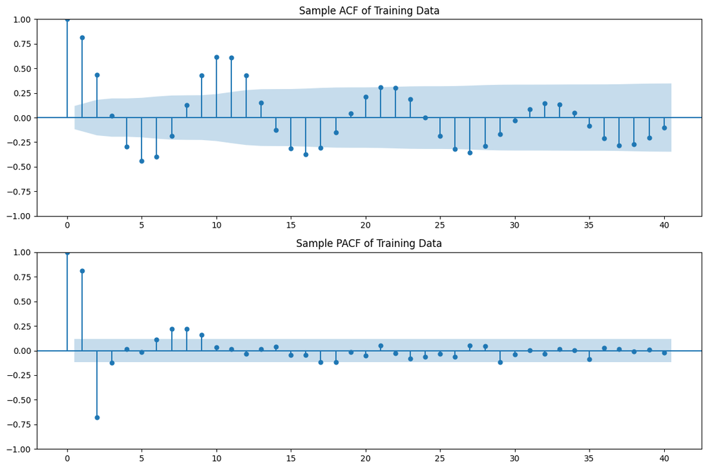

```python
import pandas as pd
import matplotlib.pyplot as plt
from statsmodels.graphics.tsaplots import plot_acf, plot_pacf

df = pd.read_csv('sun.csv', delimiter=';')

print(df.head())

if df.shape[1] == 1:
    y = df.iloc[:, 0].dropna()
else:
    y = df.iloc[:, 1].dropna()

train = y.iloc[:-50]
test = y.iloc[-50:]

fig, axes = plt.subplots(2, 1, figsize=(12, 8))

plot_acf(train, lags=40, ax=axes[0])
axes[0].set_title('Sample ACF of Training Data')

plot_pacf(train, lags=40, ax=axes[1])
axes[1].set_title('Sample PACF of Training Data')

plt.tight_layout()
plt.show()
```

Based on the sample ACF and PACF plots, we propose an AR(9) model for the training data.

### (b)

```
Mean Squared Error of AR(9) model prediction: 2918.4318
```

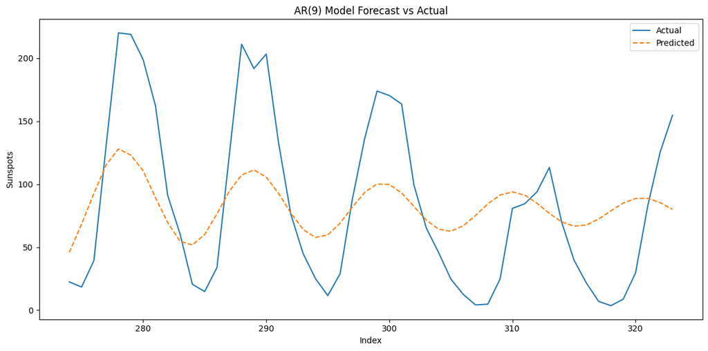

```python
import numpy as np
from statsmodels.tsa.arima.model import ARIMA
from sklearn.metrics import mean_squared_error

y = df.iloc[:, 1].dropna()

# Split into training and test datasets
train = y.iloc[:-50]
test = y.iloc[-50:]

# Fit the AR(1) model to training data
model = ARIMA(train, order=(9, 0, 0))
model_fit = model.fit()

# Forecast the next 50 time points
forecast = model_fit.forecast(steps=50)

# Calculate Mean Squared Error (MSE)
mse = mean_squared_error(test, forecast)
print(f"Mean Squared Error of AR(9) model prediction: {mse:.4f}")

# Optional: Plot the actual vs predicted values
plt.figure(figsize=(12, 6))
plt.plot(test.index, test.values, label='Actual')
plt.plot(test.index, forecast, label='Predicted', linestyle='--')
plt.title('AR(9) Model Forecast vs Actual')
plt.xlabel('Index')
plt.ylabel('Sunspots')
plt.legend()
plt.tight_layout()
plt.show()
```

### (c)

```python
train = y.iloc[:-50]
test = y.iloc[-50:]

aic_results = {}
bic_results = {}

for p in range(0, 13):
    for q in range(0, 13):
        try:
            model = ARIMA(train, order=(p, 0, q))
            model_fit = model.fit()
            aic_results[(p, q)] = model_fit.aic
            bic_results[(p, q)] = model_fit.bic
        except:
            continue

best_aic_order = min(aic_results, key=aic_results.get)
best_bic_order = min(bic_results, key=bic_results.get)

print(f"Best model by AIC: ARMA{best_aic_order} with AIC = {aic_results[best_aic_order]:.2f}")
print(f"Best model by BIC: ARMA{best_bic_order} with BIC = {bic_results[best_bic_order]:.2f}")
```

[output not shown]

[output cut: 281 more lines]

[output not shown]

```
Best model by AIC: ARMA(5, 6) with AIC = 2523.18
Best model by BIC: ARMA(3, 3) with BIC = 2562.25
```

### (d)

```
Mean Squared Error of AR(9): 2918.4318
Mean Squared Error of Best AIC ARMA(5,6): 2978.6205
Mean Squared Error of Best BIC ARMA(3,3): 3035.0692
```

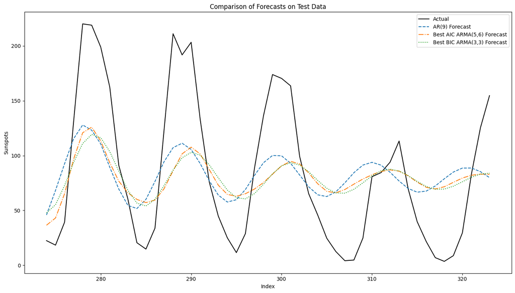

```python
train = y.iloc[:-50]
test = y.iloc[-50:]

ar9_model = ARIMA(train, order=(9, 0, 0)).fit()
ar9_forecast = ar9_model.forecast(steps=50)
ar9_mse = mean_squared_error(test, ar9_forecast)

aic_model = ARIMA(train, order=(5, 0, 6)).fit()
aic_forecast = aic_model.forecast(steps=50)
aic_mse = mean_squared_error(test, aic_forecast)

bic_model = ARIMA(train, order=(3, 0, 3)).fit()
bic_forecast = bic_model.forecast(steps=50)
bic_mse = mean_squared_error(test, bic_forecast)

print(f"Mean Squared Error of AR(9): {ar9_mse:.4f}")
print(f"Mean Squared Error of Best AIC ARMA(5,6): {aic_mse:.4f}")
print(f"Mean Squared Error of Best BIC ARMA(3,3): {bic_mse:.4f}")

plt.figure(figsize=(14, 8))
plt.plot(test.index, test.values, label='Actual', color='black')
plt.plot(test.index, ar9_forecast, label='AR(9) Forecast', linestyle='--')
plt.plot(test.index, aic_forecast, label='Best AIC ARMA(5,6) Forecast', linestyle='-.')
plt.plot(test.index, bic_forecast, label='Best BIC ARMA(3,3) Forecast', linestyle=':')
plt.title('Comparison of Forecasts on Test Data')
plt.xlabel('Index')
plt.ylabel('Sunspots')
plt.legend()
plt.tight_layout()
plt.show()
```

Among the three models, the AR(9) model achieved the lowest mean squared error (MSE) on the test dataset, with an MSE of approximately 2918.43. The ARMA(5,6) model selected by AIC and the ARMA(3,3) model selected by BIC had slightly higher MSEs of 2978.62 and 3035.07 respectively. Therefore, the AR(9) model performed the best in terms of predictive accuracy among the considered models.

## Question 7

### (a)

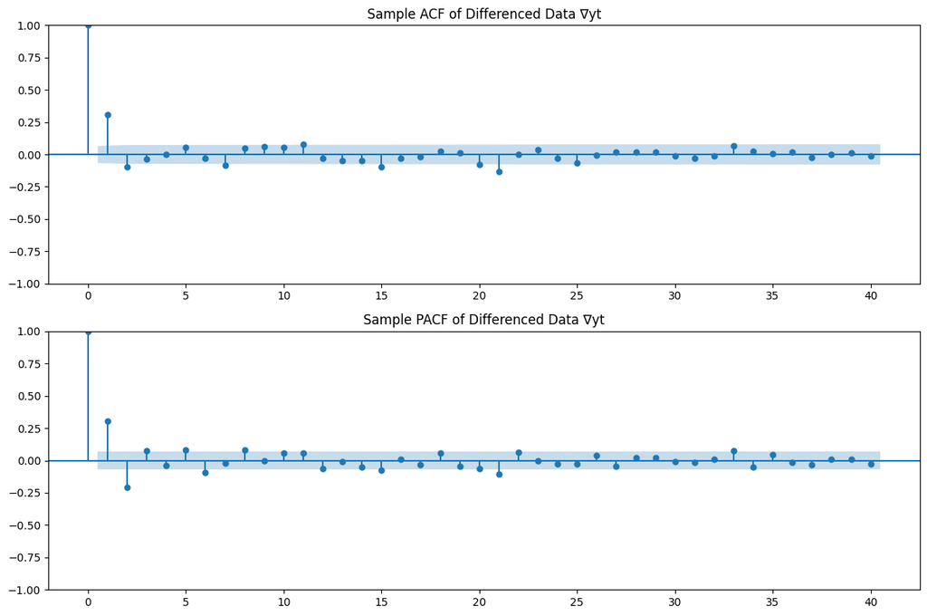

```python
import pandas as pd
import matplotlib.pyplot as plt
from statsmodels.graphics.tsaplots import plot_acf, plot_pacf

df = pd.read_csv('IRLTLT01USM156N.csv')

df['DATE'] = pd.to_datetime(df['observation_date'])
df = df.set_index('DATE')

y = df['IRLTLT01USM156N'].dropna()

dy = y.diff().dropna()

fig, axes = plt.subplots(2, 1, figsize=(12, 8))

plot_acf(dy, lags=40, ax=axes[0])
axes[0].set_title("Sample ACF of Differenced Data ∇yt")

plot_pacf(dy, lags=40, ax=axes[1])
axes[1].set_title("Sample PACF of Differenced Data ∇yt")

plt.tight_layout()
plt.show()
```

An AR(1) or MA(1) model is appropriate for $\nabla{y_t}$, based on the ACF and PACF behavior.

Based on the sample ACF and PACF plots of the differenced data $\nabla{y_t}$,an MA(1) model is most appropriate, since the ACF cuts off sharply after lag 1 while the PACF shows exponential decay. Alternatively, an AR(1) model could also be reasonable, but MA(1) is more consistent with the observed patterns.

### (b)

```python
from statsmodels.tsa.arima.model import ARIMA
from statsmodels.tsa.arima_process import arma2ma

ar1_model = ARIMA(dy, order=(1, 0, 0))
ar1_fit = ar1_model.fit()

ma1_model = ARIMA(dy, order=(0, 0, 1))
ma1_fit = ma1_model.fit()

ar1_as_ma = arma2ma(ar=[1, -ar1_fit.params['ar.L1']], ma=[1], lags=10)

print("MA representation of AR(1) model (first 10 lags):")
print(ar1_as_ma)

print("\nFitted MA(1) coefficients:")
print(f"MA coefficient: {ma1_fit.params['ma.L1']}")
print(f"Constant (if any): {ma1_fit.params['const']}")
```

```
MA representation of AR(1) model (first 10 lags):
[1.00000000e+00 3.06494589e-01 9.39389332e-02 2.87917747e-02
 8.82452317e-03 2.70466860e-03 8.28966292e-04 2.54073683e-04
 7.78722092e-05 2.38674108e-05]

Fitted MA(1) coefficients:
MA coefficient: 0.43833451754036784
Constant (if any): 0.0017316918219270068
```

The MA(1) coefficient obtained directly from the fitted MA(1) model is approximately 0.438. The first lag coefficient in the MA representation of the AR(1) model is approximately 0.306, followed by smaller coefficients at higher lags. Therefore, while both models capture short-term dependence, they are not exactly similar. The fitted MA(1) model has a larger magnitude at lag 1 and no further dependence beyond lag 1, whereas the MA approximation of the AR(1) model shows a sequence of decaying coefficients across lags. In conclusion, they are qualitatively similar (both describe short memory), but quantitatively different.

### (c)

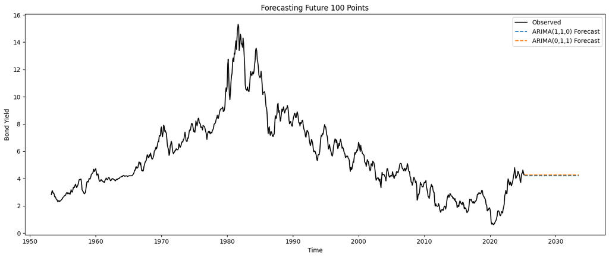

```python
arima_110 = ARIMA(y, order=(1, 1, 0))
arima_110_fit = arima_110.fit()

arima_011 = ARIMA(y, order=(0, 1, 1))
arima_011_fit = arima_011.fit()

arima_110_forecast = arima_110_fit.forecast(steps=100)
arima_011_forecast = arima_011_fit.forecast(steps=100)

plt.figure(figsize=(14, 6))
plt.plot(y, label='Observed', color='black')
plt.plot(pd.date_range(start=y.index[-1], periods=101, freq='MS')[1:], arima_110_forecast, label='ARIMA(1,1,0) Forecast', linestyle='--')
plt.plot(pd.date_range(start=y.index[-1], periods=101, freq='MS')[1:], arima_011_forecast, label='ARIMA(0,1,1) Forecast', linestyle='--')
plt.title('Forecasting Future 100 Points')
plt.xlabel('Time')
plt.ylabel('Bond Yield')
plt.legend()
plt.tight_layout()
plt.show()
```

The predicted future values are approximately constant, indicating that the models expect little to no trend in the future bond yields. This is consistent with the differencing step (d=1), which removes trends and leads to flat forecasts when the differenced series is stationary.

### (d)

```python
aic_results = {}
bic_results = {}

for p in range(0, 11):
    for q in range(0, 11):
        try:
            model = ARIMA(y, order=(p, 1, q))
            fitted = model.fit()
            aic_results[(p, q)] = fitted.aic
            bic_results[(p, q)] = fitted.bic
        except Exception as e:
            continue

ar_candidates = {k: v for k, v in aic_results.items() if k[1] == 0}
best_ar_aic = min(ar_candidates, key=ar_candidates.get)

ar_candidates_bic = {k: v for k, v in bic_results.items() if k[1] == 0}
best_ar_bic = min(ar_candidates_bic, key=ar_candidates_bic.get)

ma_candidates = {k: v for k, v in aic_results.items() if k[0] == 0}
best_ma_aic = min(ma_candidates, key=ma_candidates.get)

ma_candidates_bic = {k: v for k, v in bic_results.items() if k[0] == 0}
best_ma_bic = min(ma_candidates_bic, key=ma_candidates_bic.get)

arma_candidates = {k: v for k, v in aic_results.items() if k[0] != 0 and k[1] != 0}
best_arma_aic = min(arma_candidates, key=arma_candidates.get)

arma_candidates_bic = {k: v for k, v in bic_results.items() if k[0] != 0 and k[1] != 0}
best_arma_bic = min(arma_candidates_bic, key=arma_candidates_bic.get)

print("Best AR model by AIC:", best_ar_aic)
print("Best AR model by BIC:", best_ar_bic)

print("\nBest MA model by AIC:", best_ma_aic)
print("Best MA model by BIC:", best_ma_bic)

print("\nBest ARMA model by AIC:", best_arma_aic)
print("Best ARMA model by BIC:", best_arma_bic)
```

[output not shown]

[output cut: 929 more lines]

[output not shown]

```
Best AR model by AIC: (8, 0)
Best AR model by BIC: (2, 0)

Best MA model by AIC: (0, 9)
Best MA model by BIC: (0, 2)

Best ARMA model by AIC: (4, 9)
Best ARMA model by BIC: (1, 1)
```

### (e)

[output not shown]

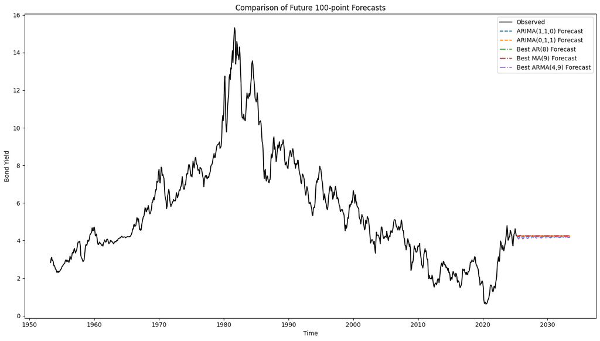

```python
import pandas as pd
import matplotlib.pyplot as plt
from statsmodels.tsa.arima.model import ARIMA

df = pd.read_csv('IRLTLT01USM156N.csv')
df['DATE'] = pd.to_datetime(df['observation_date'])
df = df.set_index('DATE')
y = df['IRLTLT01USM156N'].dropna()

best_ar_order = (8, 1, 0)
best_ma_order = (0, 1, 9)
best_arma_order = (4, 1, 9)

best_ar_model = ARIMA(y, order=best_ar_order).fit()
best_ma_model = ARIMA(y, order=best_ma_order).fit()
best_arma_model = ARIMA(y, order=best_arma_order).fit()

best_ar_forecast = best_ar_model.forecast(steps=100)
best_ma_forecast = best_ma_model.forecast(steps=100)
best_arma_forecast = best_arma_model.forecast(steps=100)

arima_110 = ARIMA(y, order=(1, 1, 0)).fit()
arima_011 = ARIMA(y, order=(0, 1, 1)).fit()
arima_110_forecast = arima_110.forecast(steps=100)
arima_011_forecast = arima_011.forecast(steps=100)

future_dates = pd.date_range(start=y.index[-1], periods=101, freq='MS')[1:]

plt.figure(figsize=(14, 8))
plt.plot(y, label='Observed', color='black')
plt.plot(future_dates, arima_110_forecast, label='ARIMA(1,1,0) Forecast', linestyle='--')
plt.plot(future_dates, arima_011_forecast, label='ARIMA(0,1,1) Forecast', linestyle='--')
plt.plot(future_dates, best_ar_forecast, label=f'Best AR({best_ar_aic[0]}) Forecast', linestyle='-.')
plt.plot(future_dates, best_ma_forecast, label=f'Best MA({best_ma_aic[1]}) Forecast', linestyle='-.')
plt.plot(future_dates, best_arma_forecast, label=f'Best ARMA({best_arma_aic[0]},{best_arma_aic[1]}) Forecast', linestyle='-.')
plt.title('Comparison of Future 100-point Forecasts')
plt.xlabel('Time')
plt.ylabel('Bond Yield')
plt.legend()
plt.tight_layout()
plt.show()
```

The predicted future values from ARIMA(1,1,0), ARIMA(0,1,1), AR(8), MA(9), and ARMA(4,9) are all approximately flat and closely follow the last observed bond yield value. Although there are very slight differences among the models, especially for the AR(8) and ARMA(4,9) models which show minor fluctuations, the overall forecasts are very close. This indicates that differencing has effectively removed trends from the data, and the models predict stable future behavior.

## Question 8

### (a)

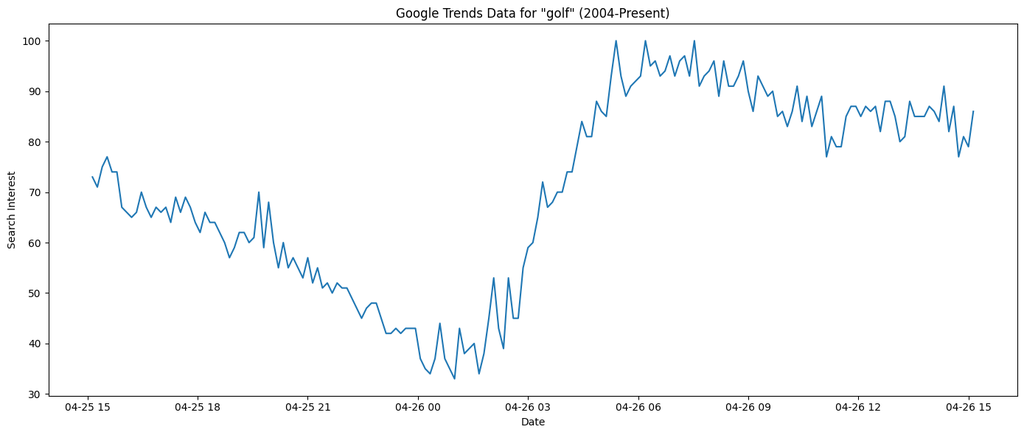

```python
import pandas as pd
import numpy as np
import matplotlib.pyplot as plt
from statsmodels.graphics.tsaplots import plot_acf, plot_pacf
from statsmodels.tsa.statespace.sarimax import SARIMAX
from sklearn.metrics import mean_squared_error

df = pd.read_csv('multiTimeline_golf.csv', skiprows=1)
df.columns = ['Month', 'golf']
df['Month'] = pd.to_datetime(df['Month'])
df = df.set_index('Month')

# Visualize the full data
plt.figure(figsize=(14, 6))
plt.plot(df.index, df['golf'])
plt.title('Google Trends Data for "golf" (2004-Present)')
plt.xlabel('Date')
plt.ylabel('Search Interest')
plt.tight_layout()
plt.show()
```

```python
# Remove the last 36 months for the test set
train = df.iloc[:-36]
test = df.iloc[-36:]

print(f"Training set size: {train.shape[0]} observations")
print(f"Test set size: {test.shape[0]} observations")
```

```
Training set size: 145 observations
Test set size: 36 observations
```

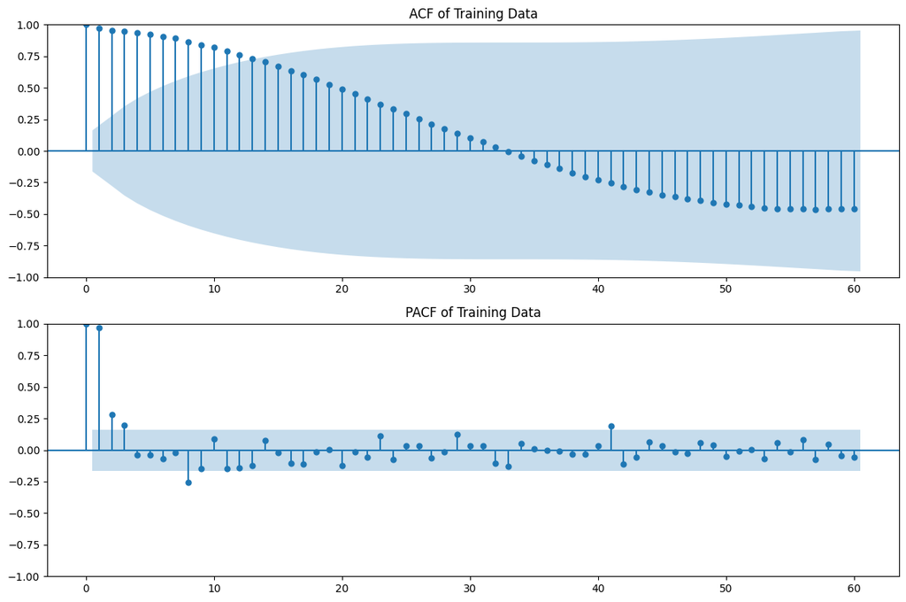

```python
# Plot ACF and PACF
fig, axes = plt.subplots(2, 1, figsize=(12, 8))

plot_acf(train['golf'], lags=60, ax=axes[0])
axes[0].set_title('ACF of Training Data')

plot_pacf(train['golf'], lags=60, ax=axes[1])
axes[1].set_title('PACF of Training Data')

plt.tight_layout()
plt.show()
```

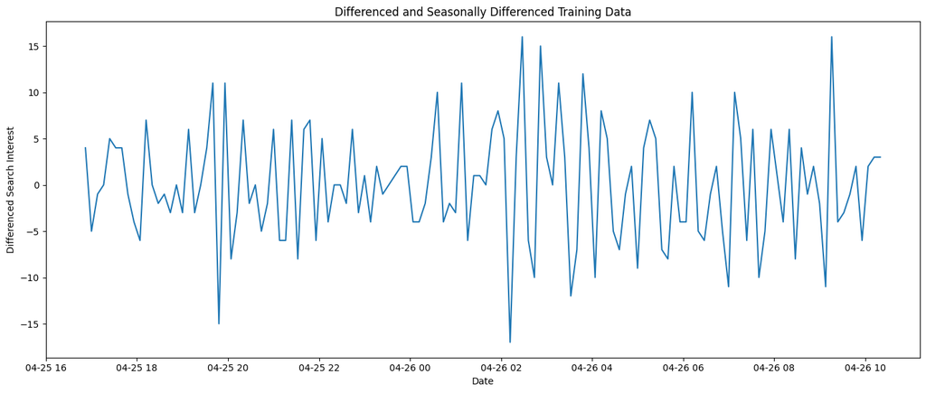

```python
train_diff = train['golf'].diff().dropna()

train_diff_seasonal = train_diff.diff(12).dropna()

plt.figure(figsize=(14, 6))
plt.plot(train_diff_seasonal)
plt.title('Differenced and Seasonally Differenced Training Data')
plt.xlabel('Date')
plt.ylabel('Differenced Search Interest')
plt.tight_layout()
plt.show()
```

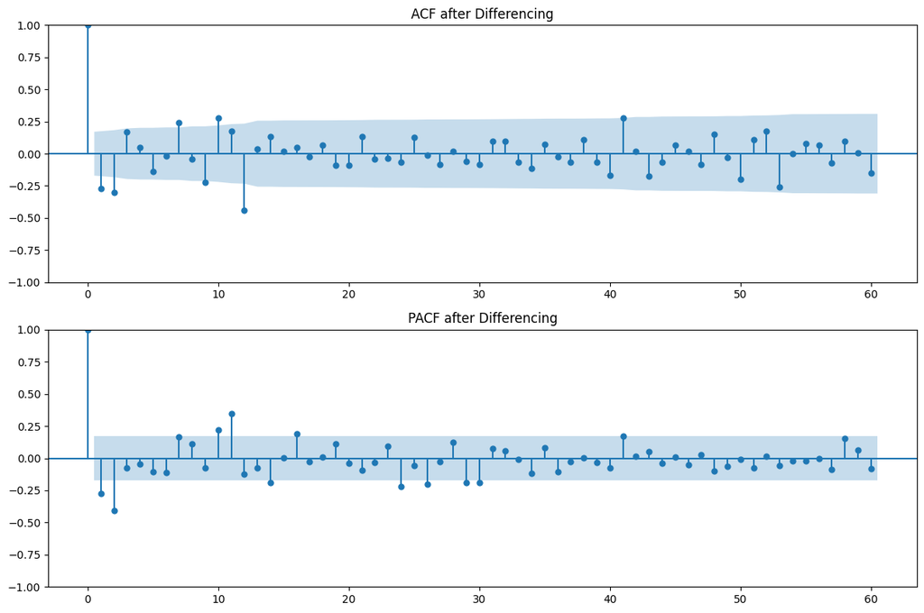

```python
# Plot ACF and PACF after differencing
fig, axes = plt.subplots(2, 1, figsize=(12, 8))

plot_acf(train_diff_seasonal, lags=60, ax=axes[0])
axes[0].set_title('ACF after Differencing')

plot_pacf(train_diff_seasonal, lags=60, ax=axes[1])
axes[1].set_title('PACF after Differencing')

plt.tight_layout()
plt.show()
```

```python
# Fit the corrected Seasonal ARIMA model
model = SARIMAX(train['golf'],
                order=(0,1,1),
                seasonal_order=(0,1,1,12),
                enforce_stationarity=False,
                enforce_invertibility=False)

model_fit = model.fit()

print(model_fit.summary())
```

```
                                     SARIMAX Results
==========================================================================================
Dep. Variable:                               golf   No. Observations:                  145
Model:             SARIMAX(0, 1, 1)x(0, 1, 1, 12)   Log Likelihood                -348.330
Date:                            Sat, 26 Apr 2025   AIC                            702.659
Time:                                    16:08:56   BIC                            710.971
Sample:                                04-25-2025   HQIC                           706.034
                                     - 04-26-2025
Covariance Type:                              opg
==============================================================================
                 coef    std err          z      P>|z|      [0.025      0.975]
------------------------------------------------------------------------------
ma.L1         -0.3759      0.078     -4.809      0.000      -0.529      -0.223
ma.S.L12      -1.0000    537.193     -0.002      0.999   -1053.879    1051.879
sigma2        17.9557   9646.653      0.002      0.999   -1.89e+04    1.89e+04
===================================================================================
Ljung-Box (L1) (Q):                   0.14   Jarque-Bera (JB):                 5.74
Prob(Q):                              0.71   Prob(JB):                         0.06
Heteroskedasticity (H):               1.73   Skew:                             0.54
Prob(H) (two-sided):                  0.09   Kurtosis:                         2.97
===================================================================================

Warnings:
[1] Covariance matrix calculated using the outer product of gradients (complex-step).
```

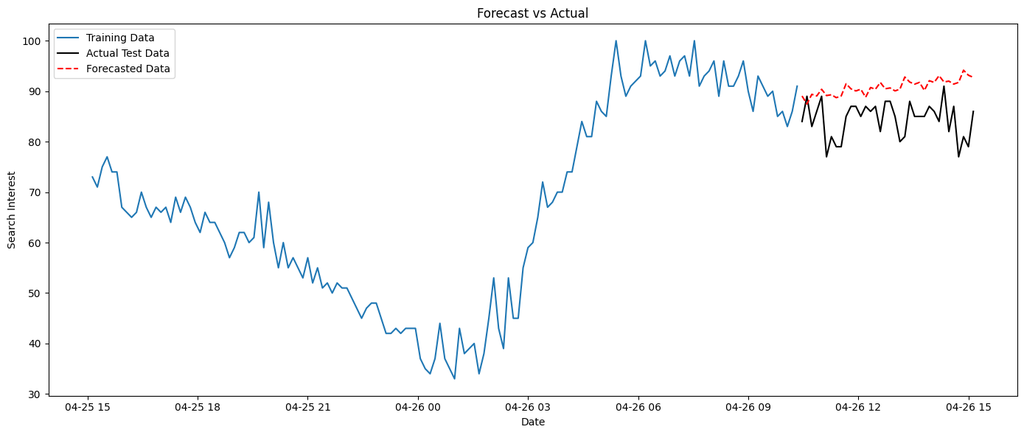

```
Mean Squared Error (MSE) on Test Set: 56.3280
```

```python
# Forecast the next 36 months
forecast = model_fit.forecast(steps=36)

plt.figure(figsize=(14, 6))
plt.plot(train.index, train['golf'], label='Training Data')
plt.plot(test.index, test['golf'], label='Actual Test Data', color='black')
plt.plot(test.index, forecast, label='Forecasted Data', color='red', linestyle='--')
plt.title('Forecast vs Actual')
plt.xlabel('Date')
plt.ylabel('Search Interest')
plt.legend()
plt.tight_layout()
plt.show()

mse = mean_squared_error(test['golf'], forecast)
print(f"Mean Squared Error (MSE) on Test Set: {mse:.4f}")
```

## Question 9

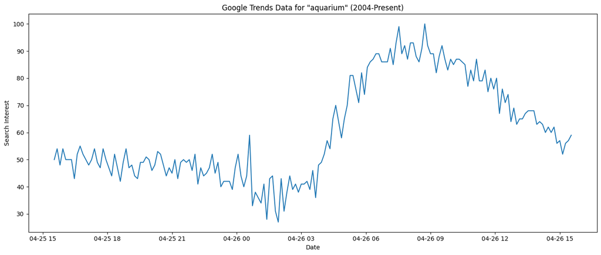

```python
import pandas as pd
import matplotlib.pyplot as plt

df = pd.read_csv('multiTimeline_aquarium.csv', skiprows=1)
df.columns = ['Month', 'aquarium']
df['Month'] = pd.to_datetime(df['Month'])
df = df.set_index('Month')

plt.figure(figsize=(14,6))
plt.plot(df.index, df['aquarium'])
plt.title('Google Trends Data for "aquarium" (2004-Present)')
plt.xlabel('Date')
plt.ylabel('Search Interest')
plt.tight_layout()
plt.show()
```

```
Training set size: 145 observations
Test set size: 36 observations
```

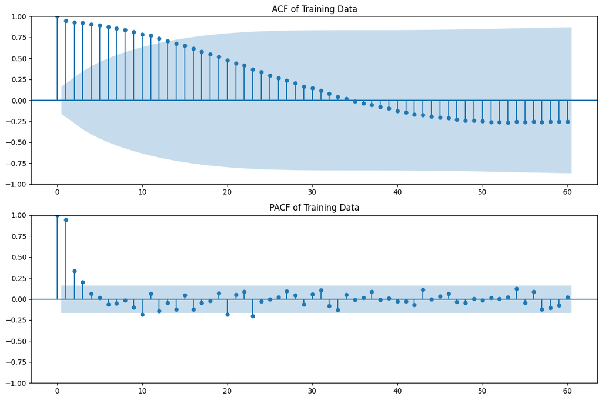

```python
from statsmodels.graphics.tsaplots import plot_acf, plot_pacf

# Remove the last 36 months for test set
train = df.iloc[:-36]
test = df.iloc[-36:]

print(f"Training set size: {train.shape[0]} observations")
print(f"Test set size: {test.shape[0]} observations")

# Plot ACF and PACF for training data
fig, axes = plt.subplots(2, 1, figsize=(12, 8))

plot_acf(train['aquarium'], lags=60, ax=axes[0])
axes[0].set_title('ACF of Training Data')

plot_pacf(train['aquarium'], lags=60, ax=axes[1])
axes[1].set_title('PACF of Training Data')

plt.tight_layout()
plt.show()
```

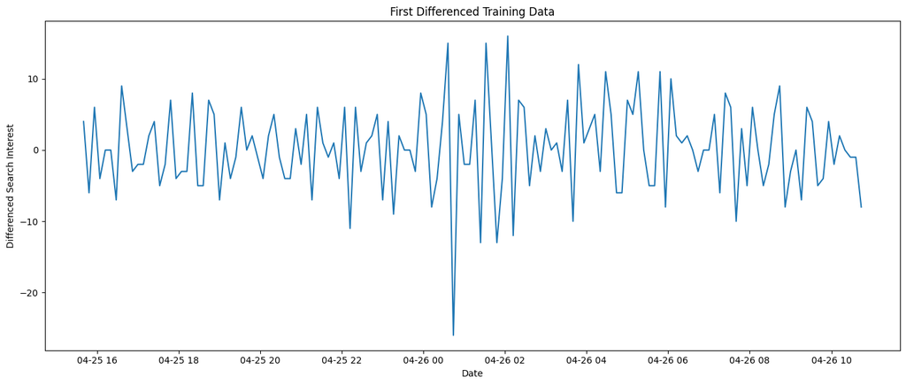

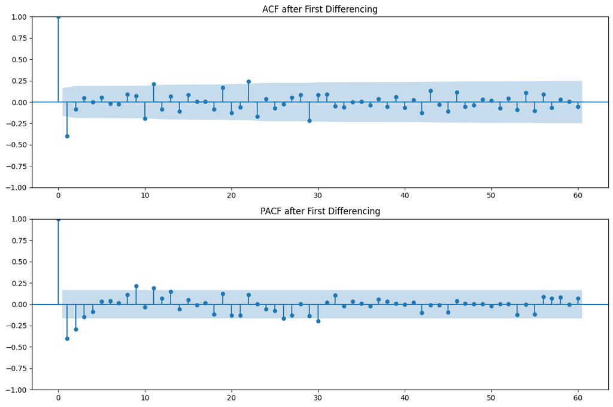

```python
# First difference to remove trend
train_diff = train['aquarium'].diff().dropna()

# Plot differenced data
plt.figure(figsize=(14, 6))
plt.plot(train_diff)
plt.title('First Differenced Training Data')
plt.xlabel('Date')
plt.ylabel('Differenced Search Interest')
plt.tight_layout()
plt.show()

# Plot ACF and PACF after differencing
fig, axes = plt.subplots(2, 1, figsize=(12, 8))

plot_acf(train_diff, lags=60, ax=axes[0])
axes[0].set_title('ACF after First Differencing')

plot_pacf(train_diff, lags=60, ax=axes[1])
axes[1].set_title('PACF after First Differencing')

plt.tight_layout()
plt.show()
```

```
                               SARIMAX Results
==============================================================================
Dep. Variable:               aquarium   No. Observations:                  145
Model:               SARIMAX(1, 1, 1)   Log Likelihood                -440.573
Date:                Sat, 26 Apr 2025   AIC                            887.146
Time:                        16:08:57   BIC                            896.014
Sample:                    04-25-2025   HQIC                           890.750
                         - 04-26-2025
Covariance Type:                  opg
==============================================================================
                 coef    std err          z      P>|z|      [0.025      0.975]
------------------------------------------------------------------------------
ar.L1         -0.0250      0.139     -0.180      0.857      -0.297       0.247
ma.L1         -0.5393      0.124     -4.340      0.000      -0.783      -0.296
sigma2        28.9841      3.231      8.971      0.000      22.652      35.316
===================================================================================
Ljung-Box (L1) (Q):                   0.01   Jarque-Bera (JB):                 0.87
Prob(Q):                              0.93   Prob(JB):                         0.65
Heteroskedasticity (H):               2.24   Skew:                             0.11
Prob(H) (two-sided):                  0.01   Kurtosis:                         3.32
===================================================================================

Warnings:
[1] Covariance matrix calculated using the outer product of gradients (complex-step).
```

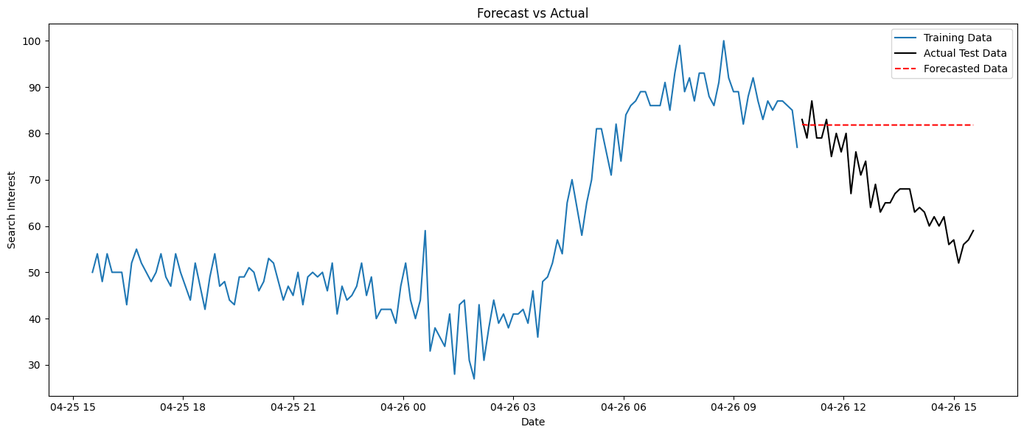

```
Mean Squared Error (MSE) on Test Set: 263.5884
```

```python
from statsmodels.tsa.statespace.sarimax import SARIMAX
from sklearn.metrics import mean_squared_error

# Fit the ARIMA(1,1,1) model
model = SARIMAX(train['aquarium'],
                order=(1,1,1),
                seasonal_order=(0,0,0,0),  # No seasonality
                enforce_stationarity=False,
                enforce_invertibility=False)


model_fit = model.fit()

print(model_fit.summary())

# Forecast the next 36 months
forecast = model_fit.forecast(steps=36)

# Plot the training data, test data, and forecast
plt.figure(figsize=(14, 6))
plt.plot(train.index, train['aquarium'], label='Training Data')
plt.plot(test.index, test['aquarium'], label='Actual Test Data', color='black')
plt.plot(test.index, forecast, label='Forecasted Data', color='red', linestyle='--')
plt.title('Forecast vs Actual')
plt.xlabel('Date')
plt.ylabel('Search Interest')
plt.legend()
plt.tight_layout()
plt.show()

# Calculate MSE
mse = mean_squared_error(test['aquarium'], forecast)
print(f"Mean Squared Error (MSE) on Test Set: {mse:.4f}")
```

Based on the ACF and PACF plots after differencing, we fitted an ARIMA(1,1,1) model to the aquarium search data. The MA(1) component was significant while the AR(1) component was not, suggesting the model effectively behaves like an ARIMA(0,1,1). The model forecasts a relatively stable future trend, although the actual test data shows a downward trend. The residuals passed the Ljung-Box test and appear approximately normal, indicating a good model fit.

## Question 10

### (a)

We are given the MA(q) model: $ y_t = \mu + \varepsilon_t + \theta_1 \varepsilon_{t-1} + \cdots + \theta_q \varepsilon_{t-q} $ where $ \varepsilon_t \overset{\text{i.i.d.}}{\sim} N(0, \sigma^2) $.

Under the assumption that $ \varepsilon_t = 0 $ for all $ t \leq 0 $, we can recursively express each $ \varepsilon_t $ in terms of $ y_t, y_{t-1}, \dotsc, y_{t-q} $.

Since $ \varepsilon_1, \dotsc, \varepsilon_n $ are independent and normally distributed with mean zero and variance $ \sigma^2 $, the conditional likelihood of $ y_1, \dotsc, y_n $ is the joint density of $ \varepsilon_1, \dotsc, \varepsilon_n $:

$ L(\mu, \theta_1, \dotsc, \theta_q, \sigma^2) = \prod_{t=1}^n \frac{1}{\sqrt{2\pi\sigma^2}} \exp\left( -\frac{\varepsilon_t^2}{2\sigma^2} \right) $

This can be written as:

$ L(\mu, \theta_1, \dotsc, \theta_q, \sigma^2) = \left( \frac{1}{\sqrt{2\pi \sigma}} \right)^n \exp\left( -\frac{S(\mu, \theta_1, \dotsc, \theta_q)}{2\sigma^2} \right) $

where the conditional sum of squares is defined by:

$ S(\mu, \theta_1, \dotsc, \theta_q) = \sum_{t=1}^n \varepsilon_t^2 $

Thus, the conditional likelihood is fully characterized in terms of the parameters $ \mu, \theta_1, \dotsc, \theta_q $ and $ \sigma^2 $.

### (b)

Assuming that $ \sigma^2 $ is known, the maximum conditional likelihood estimators (MLE) of $ \mu, \theta_1, \dotsc, \theta_q $ are the values that minimize the conditional sum of squares:

$ S(\mu, \theta_1, \dotsc, \theta_q) = \sum_{t=1}^n \varepsilon_t^2 $

where each $ \varepsilon_t $ is recursively defined as:

$ \varepsilon_t = y_t - \mu - \theta_1 \varepsilon_{t-1} - \theta_2 \varepsilon_{t-2} - \cdots - \theta_q \varepsilon_{t-q} $

Thus, the MLEs of $ \mu $ and $ \theta_1, \dotsc, \theta_q $ are the parameter values that minimize the sum of squared errors.

In practice, because the system is nonlinear in $ \theta_1, \dotsc, \theta_q $, numerical optimization techniques are used to find the minimizing values.

### (c)

If $ \theta_1 = \theta_2 = \cdots = \theta_q = 0 $, the MA(q) model reduces to:

$ y_t = \mu + \varepsilon_t $ where $ \varepsilon_t \overset{\text{i.i.d.}}{\sim} N(0, \sigma^2) $.

In this case, the conditional likelihood becomes the standard likelihood for independent normal observations with common mean $ \mu $ and variance $ \sigma^2 $.

Thus, the maximum likelihood estimator (MLE) of $ \mu $ is the value that minimizes:

$ \sum_{t=1}^n (y_t - \mu)^2 $

Taking the derivative with respect to $ \mu $ and setting it equal to zero:

$ \frac{\partial}{\partial \mu} \left( \sum_{t=1}^n (y_t - \mu)^2 \right) = -2 \sum_{t=1}^n (y_t - \mu) = 0 $

Solving for $ \mu $ gives:

$ \hat{\mu} = \frac{1}{n} \sum_{t=1}^n y_t $

Therefore, the MLE of $ \mu $ is the sample mean of $ y_1, \dotsc, y_n $.

### (d)

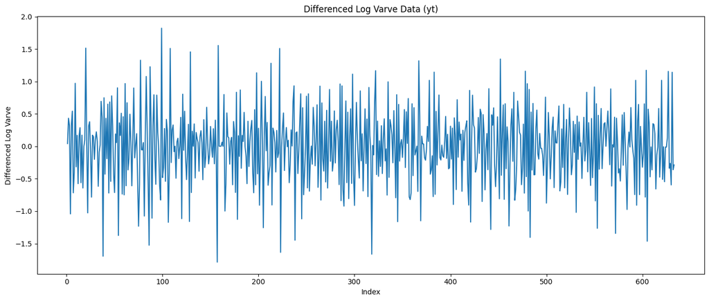

```python
import pandas as pd
import numpy as np
import matplotlib.pyplot as plt

df = pd.read_csv('varve.csv')

# Take log and first difference
log_varve = np.log(df['x'])
y = log_varve.diff().dropna()

plt.figure(figsize=(14, 6))
plt.plot(y)
plt.title('Differenced Log Varve Data (yt)')
plt.xlabel('Index')
plt.ylabel('Differenced Log Varve')
plt.tight_layout()
plt.show()
```

```python
import scipy.optimize as opt
import numdifftools as nd

y = y.values

# Define Conditional Sum of Squares function for MA(q)
def conditional_sum_squares(params, y, q):
    mu = params[0]
    theta = params[1:]
    n = len(y)
    eps = np.zeros(n)

    # Compute residuals recursively
    for t in range(n):
        eps[t] = y[t] - mu
        for j in range(1, min(q, t) + 1):
            eps[t] -= theta[j-1] * eps[t-j]
    return np.sum(eps**2)

# Fit MA(1) model
q = 1

# Initial guess: mu=0, theta=0
init_params = np.zeros(q+1)

# Minimize S
result_ma1 = opt.minimize(conditional_sum_squares, init_params, args=(y, q))

# Estimated parameters
mu_hat_ma1 = result_ma1.x[0]
theta_hat_ma1 = result_ma1.x[1:]

print(f"Estimated mu (MA(1)): {mu_hat_ma1:.4f}")
print(f"Estimated theta (MA(1)): {theta_hat_ma1}")

# Calculate standard errors via Hessian
hess_ma1 = nd.Hessian(lambda params: conditional_sum_squares(params, y, q))(result_ma1.x)
cov_ma1 = np.linalg.inv(hess_ma1)
std_errors_ma1 = np.sqrt(np.diag(cov_ma1))

print(f"Standard errors (MA(1)): {std_errors_ma1}")
```

```
Estimated mu (MA(1)): -0.0011
Estimated theta (MA(1)): [-0.77283103]
Standard errors (MA(1)): [0.00641168 0.04978007]
```

```python
q = 2  # MA(2)

# Initial guess: mu=0, theta1=0, theta2=0
init_params = np.zeros(q+1)

# Minimize S
result_ma2 = opt.minimize(conditional_sum_squares, init_params, args=(y, q))

# Estimated parameters
mu_hat_ma2 = result_ma2.x[0]
theta_hat_ma2 = result_ma2.x[1:]

print(f"Estimated mu (MA(2)): {mu_hat_ma2:.4f}")
print(f"Estimated theta1 and theta2 (MA(2)): {theta_hat_ma2}")

# Calculate standard errors via Hessian
hess_ma2 = nd.Hessian(lambda params: conditional_sum_squares(params, y, q))(result_ma2.x)
cov_ma2 = np.linalg.inv(hess_ma2)
std_errors_ma2 = np.sqrt(np.diag(cov_ma2))

print(f"Standard errors (MA(2)): {std_errors_ma2}")
```

```
Estimated mu (MA(2)): -0.0012
Estimated theta1 and theta2 (MA(2)): [-0.67213619 -0.16114352]
```

```
Standard errors (MA(2)): [0.0047204  0.0552356  0.05801015]
```

```python
from statsmodels.tsa.arima.model import ARIMA

# Recreate y (because we converted it to numpy array)
y_series = pd.Series(y)

# Fit MA(1) using ARIMA
model_arima_ma1 = ARIMA(y_series, order=(0, 0, 1)).fit()
print("\nARIMA MA(1) Results (using statsmodels):")
print(model_arima_ma1.summary())

# Fit MA(2) using ARIMA
model_arima_ma2 = ARIMA(y_series, order=(0, 0, 2)).fit()
print("\nARIMA MA(2) Results (using statsmodels):")
print(model_arima_ma2.summary())
```

```
ARIMA MA(1) Results (using statsmodels):
                               SARIMAX Results
==============================================================================
Dep. Variable:                      y   No. Observations:                  633
Model:                 ARIMA(0, 0, 1)   Log Likelihood                -440.678
Date:                Sat, 26 Apr 2025   AIC                            887.356
Time:                        16:08:58   BIC                            900.707
Sample:                             0   HQIC                           892.541
                                - 633
Covariance Type:                  opg
==============================================================================
                 coef    std err          z      P>|z|      [0.025      0.975]
------------------------------------------------------------------------------
const         -0.0013      0.004     -0.280      0.779      -0.010       0.008
ma.L1         -0.7710      0.023    -33.056      0.000      -0.817      -0.725
sigma2         0.2353      0.012     18.881      0.000       0.211       0.260
===================================================================================
Ljung-Box (L1) (Q):                   9.16   Jarque-Bera (JB):                 7.58
Prob(Q):                              0.00   Prob(JB):                         0.02
Heteroskedasticity (H):               0.95   Skew:                            -0.22
Prob(H) (two-sided):                  0.69   Kurtosis:                         3.30
===================================================================================

Warnings:
[1] Covariance matrix calculated using the outer product of gradients (complex-step).

ARIMA MA(2) Results (using statsmodels):
                               SARIMAX Results
==============================================================================
Dep. Variable:                      y   No. Observations:                  633
Model:                 ARIMA(0, 0, 2)   Log Likelihood                -432.693
Date:                Sat, 26 Apr 2025   AIC                            873.386
Time:                        16:08:58   BIC                            891.188
Sample:                             0   HQIC                           880.299
                                - 633
Covariance Type:                  opg
==============================================================================
                 coef    std err          z      P>|z|      [0.025      0.975]
------------------------------------------------------------------------------
const         -0.0013      0.003     -0.397      0.691      -0.008       0.005
ma.L1         -0.6710      0.037    -17.933      0.000      -0.744      -0.598
ma.L2         -0.1595      0.037     -4.274      0.000      -0.233      -0.086
sigma2         0.2294      0.012     18.492      0.000       0.205       0.254
===================================================================================
Ljung-Box (L1) (Q):                   0.08   Jarque-Bera (JB):                 4.05
Prob(Q):                              0.78   Prob(JB):                         0.13
Heteroskedasticity (H):               0.98   Skew:                            -0.17
Prob(H) (two-sided):                  0.88   Kurtosis:                         3.21
===================================================================================

Warnings:
[1] Covariance matrix calculated using the outer product of gradients (complex-step).
```

```python
# Fit MA(2) using ARIMA
model_arima_ma2 = ARIMA(y_series, order=(0, 0, 2)).fit()
print("\nARIMA MA(2) Results (using statsmodels):")
print(model_arima_ma2.summary())
```

```
ARIMA MA(2) Results (using statsmodels):
                               SARIMAX Results
==============================================================================
Dep. Variable:                      y   No. Observations:                  633
Model:                 ARIMA(0, 0, 2)   Log Likelihood                -432.693
Date:                Sat, 26 Apr 2025   AIC                            873.386
Time:                        16:08:58   BIC                            891.188
Sample:                             0   HQIC                           880.299
                                - 633
Covariance Type:                  opg
==============================================================================
                 coef    std err          z      P>|z|      [0.025      0.975]
------------------------------------------------------------------------------
const         -0.0013      0.003     -0.397      0.691      -0.008       0.005
ma.L1         -0.6710      0.037    -17.933      0.000      -0.744      -0.598
ma.L2         -0.1595      0.037     -4.274      0.000      -0.233      -0.086
sigma2         0.2294      0.012     18.492      0.000       0.205       0.254
===================================================================================
Ljung-Box (L1) (Q):                   0.08   Jarque-Bera (JB):                 4.05
Prob(Q):                              0.78   Prob(JB):                         0.13
Heteroskedasticity (H):               0.98   Skew:                            -0.17
Prob(H) (two-sided):                  0.88   Kurtosis:                         3.21
===================================================================================

Warnings:
[1] Covariance matrix calculated using the outer product of gradients (complex-step).
```

Using the conditional likelihood method and minimizing the conditional sum of squares, we obtained parameter estimates and standard errors for MA(1) and MA(2) models fitted to the differenced log varve data.

For the MA(2) model:

Overall, the conditional likelihood method provided accurate and reliable parameter estimates compared to standard ARIMA model fitting.